**Dynamical Systems:**  
**Representations of LTI System**

Table of Contents

# 1. Transfer Function

The transfer function of a system is defined as the ratio of the Laplace transforms of the output and input, assuming zero initial conditions:

$$ G(s) = \frac{Y(s)}{X(s)} $$

**Equation of Motion**

Consider a mass-spring-damper system governed by the second-order differential equation:

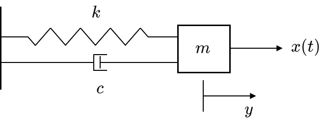

$$ m\ddot{y}(t) + c\dot{y}(t) + ky(t) = x(t) $$

**Laplace Transform**

Taking the Laplace transform of both sides (with zero initial conditions):

$$ (ms^2 + cs + k)Y(s) = X(s) $$

Solving for the transfer function:

$$ G(s) = \frac{Y(s)}{X(s)} = \frac{1}{ms^2 + cs + k} $$

This transfer function fully characterizes the input-output behavior of the system in the Laplace domain.

**Block Diagram**

Below is the block diagram representation of the system:

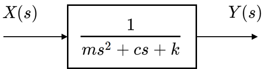

**Example**

Consider the following transfer function:

$$G(s) = \frac{s+5}{s^4+2s^3+3s^2+4s+5}$$

```matlab
num = [1,5];
den = [1,2,3,4,5];

G = tf(num,den)
```

```
G =

              s + 5
  -----------------------------
  s^4 + 2 s^3 + 3 s^2 + 4 s + 5

Continuous-time transfer function.
```

# 2. State Space Representation

$$ \begin{align*} \dot{x} & = Ax + Bu \\ y & = Cx + Du \end{align*} $$

**MATLAB Code for State-Space Representation**

```matlab
A = [2.25,-5,-1.25,-0.5;
     2.25,-4.25,-1.25,-0.25;
     0.25,-0.5,-1.25,-1;
     1.25,-1.75,-0.25,-0.75];

B = [4,6;
     2,4;
     2,2;
     0,2];

C = [0,0,0,1;
     0,2,0,2];

D = zeros(2,2);

G = ss(A,B,C,D)
```

```
G =

  A =
          x1     x2     x3     x4
   x1   2.25     -5  -1.25   -0.5
   x2   2.25  -4.25  -1.25  -0.25
   x3   0.25   -0.5  -1.25     -1
   x4   1.25  -1.75  -0.25  -0.75

  B =
       u1  u2
   x1   4   6
   x2   2   4
   x3   2   2
   x4   0   2

  C =
       x1  x2  x3  x4
   y1   0   0   0   1
   y2   0   2   0   2

  D =
       u1  u2
   y1   0   0
   y2   0   0

Continuous-time state-space model.
```

```matlab
G.A
```

```
ans =

    2.2500   -5.0000   -1.2500   -0.5000
    2.2500   -4.2500   -1.2500   -0.2500
    0.2500   -0.5000   -1.2500   -1.0000
    1.2500   -1.7500   -0.2500   -0.7500
```

$$D(s) = s^4+4s^3+6.25s^2+5.25s + 2.25$$

```matlab
D = poly(G.A)
```

```
D =

    1.0000    4.0000    6.2500    5.2500    2.2500
```

# 3. Three Representations of Linear Systems

Linear systems can be described equivalently in three domains, each offering different insights and tools for analysis:

(1) Time-Domain Representation

Convolution integral:

$$ y(t) = \int_0^t h(t - \tau) u(\tau) \, d\tau $$

- Describes how the system's impulse response $h(t)$ combines with the input $u(t)$
- Fundamental for understanding causality, memory, and transient behavior
- Applicable in both continuous and discrete time

(2) Frequency-Domain Representation

Transfer function:

$$ G(s) = \frac{Y(s)}{U(s)} = C(sI - A)^{-1}B + D $$

- Characterizes how the system filters input signals in the Laplace domain
- Facilitates algebraic manipulation and analysis of stability, resonance, and frequency response
- Converts differential equations into rational functions

(3) State-Space Representation

State equations:

$$ \dot{x} = Ax + Bu, \qquad y = Cx + Du $$

- A compact and general framework for multi-input, multi-output (MIMO) systems
- Suitable for control design, observability, and feedback implementation
- Encodes internal system dynamics using state variables

**Conversions Between Representations**

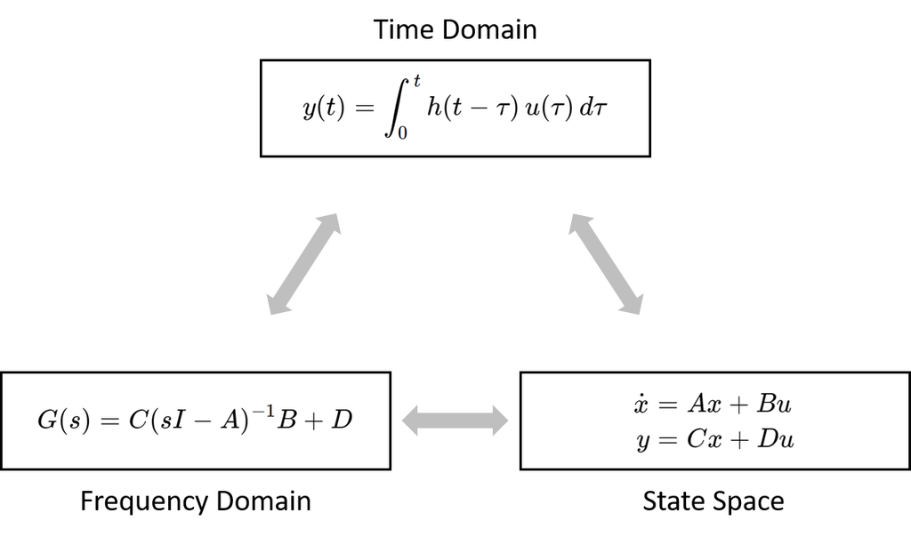

Each representation can be transformed into the others:

- From state-space to transfer function:

$$ G(s) = C(sI - A)^{-1}B + D $$

- From impulse response to transfer function:

$$ G(s) = \mathcal{L}\{h(t)\} $$

- From state-space to impulse response:

$$ h(t) = Ce^{At}B + D\delta(t) $$

These equivalences allow flexibility in analysis and design, depending on the nature of the system and the goals of the study.

- In linear system, convolution operation can be converted to product operation through Laplace transform.

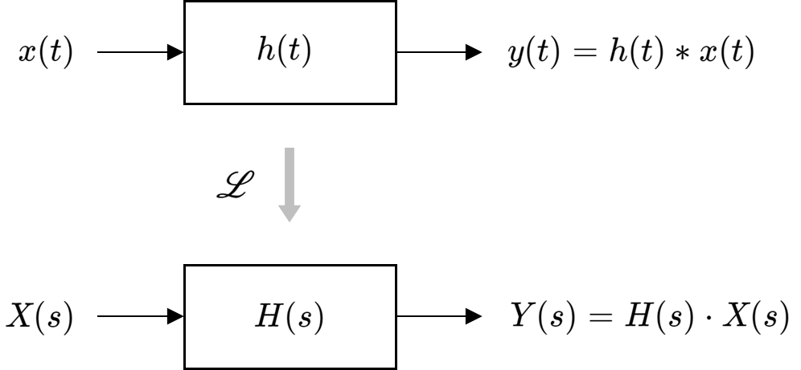

## 3.1. Converting from State-Space to Transfer Function

A linear time-invariant (LTI) system in state-space form is given by:

$$ \begin{aligned} \dot{x}(t) &= Ax(t) + Bu(t) \\ y(t) &= Cx(t) + Du(t) \end{aligned} $$

To derive the transfer function of the system, we apply the Laplace transform (assuming zero initial conditions):

$$ \begin{aligned} sX(s) &= AX(s) + BU(s) \\ Y(s) &= CX(s) + DU(s) \end{aligned} $$

Solving the first equation for $X(s)$:

$$ (sI - A)X(s) = BU(s) \quad \Rightarrow \quad X(s) = (sI - A)^{-1}BU(s) $$

Substitute this into the output equation:

$$ \begin{aligned} Y(s) &= C(sI - A)^{-1}BU(s) + DU(s) \\ &= \left[C(sI - A)^{-1}B + D\right]U(s) \end{aligned} $$

Thus, the transfer function from input $u(t)$ to output $y(t)$ is:

$$ G(s) = \frac{Y(s)}{U(s)} = C(sI - A)^{-1}B + D $$

This expression is often referred to as the transfer function matrix in MIMO systems.

**Series Expansions and the Matrix Exponential**

(1) Series Expansion of $(I - C)^{-1}$

For any matrix $C$ such that the spectral radius $\rho(C) < 1$, the Neumann series converges:

$$ (I - C)^{-1} = I + C + C^2 + C^3 + \cdots $$

This expansion is analogous to the scalar geometric series:

$$ \frac{1}{1 - r} = 1 + r + r^2 + \cdots, \quad \text{for } |r| < 1 $$

(2) Series Expansion of $(sI - A)^{-1}$

To relate the transfer function matrix to the matrix exponential, consider the series expansion of $(sI - A)^{-1}$. Factoring out $\frac{1}{s}$:

$$(sI - A)^{-1} = \left(\frac{1}{s}\right) \left(I - \frac{A}{s}\right)^{-1} = \frac{I}{s} + \frac{A}{s^2} + \frac{A^2}{s^3} + \cdots = \sum_{k=0}^{\infty} \frac{A^k}{s^{k+1}}$$

This is a matrix power series in $\frac{1}{s}$, and it converges for large $|s|$ (i.e., when $\|A/s\| < 1$).

(3) Inverse Laplace Transform of the Series

Taking the inverse Laplace transform term by term:

$$\mathcal{L}^{-1} \left( \frac{I}{s} + \frac{A}{s^2} + \frac{A^2}{s^3} + \cdots \right) = I + At + \frac{(At)^2}{2!} + \cdots = e^{At} \qquad \text{or}$$

$$ \mathcal{L}^{-1}\left( \sum_{k=0}^{\infty} \frac{A^k}{s^{k+1}} \right) = \sum_{k=0}^{\infty} \frac{A^k t^k}{k!} = e^{At} $$

Thus,

$$ \mathcal{L}\{e^{At}\} = (sI - A)^{-1} $$

This result plays a central role in state-space analysis and is used to solve homogeneous linear systems.

**Time-Domain Interpretation**

In the time domain, the output is given by:

$$ y(t) = Ce^{At}x(0) + \int_0^t C e^{A(t - \tau)} Bu(\tau) \, d\tau + Du(t) $$

This decomposition separates the system response into:

- The homogeneous response due to initial state: $Ce^{At}x(0)$
- The forced response due to input $u(t)$: convolution with $C e^{At} B$
- The direct feedthrough (if $D \neq 0$): $Du(t)$

## 3.2. Transformation of State-Space Models

In state-space modeling, the representation of a system is not unique. That is, multiple state-space realizations can represent the same input-output behavior (i.e., the same transfer function).

This arises because the choice of the state vector is not unique—any invertible linear transformation of the state still yields a valid model of the system.

**Equivalent State Representations**

Suppose we are given a linear time-invariant system described by:

$$ \begin{aligned} \dot{x} &= A x + B u \\ y &= C x + D u \end{aligned} $$

Let us define a new state variable:

$$ x = T z $$

where $T \in \mathbb{R}^{n \times n}$ is an invertible matrix (i.e., a similarity transformation), and $z$ is the new state vector.

**Transforming the System**

Substituting $x = Tz$ into the original state equation:

$$ \begin{aligned} \dot{x} &= A x + B u = A T z + B u \\ T \dot{z} &= A T z + B u \\ \dot{z} &= T^{-1} A T z + T^{-1} B u \end{aligned} $$

The output equation becomes:

$$ y = C x + D u = C T z + D u $$

**Resulting Transformed System**

The transformed state-space model is:

$$ \begin{aligned} \dot{z} &= \bar{A} z + \bar{B} u \\ y &= \bar{C} z + \bar{D} u \end{aligned} $$

where:

$$ \bar{A} = T^{-1} A T, \qquad \bar{B} = T^{-1} B, \qquad \bar{C} = C T, \qquad \bar{D} = D $$

**Do the Two Representations Yield the Same Transfer Function?**

Yes. Let us compute the transfer functions of both representations.

Original model:

$$ G_1(s) = C(sI - A)^{-1} B + D $$

Transformed model:

$$ G_2(s) = \bar{C}(sI - \bar{A})^{-1} \bar{B} + \bar{D} $$

Now substitute the expressions for $\bar{A}, \bar{B}, \bar{C}, \bar{D}$:

$$ \begin{aligned} G_2(s) &= C T \left( sI - T^{-1} A T \right)^{-1} T^{-1} B + D \\ &= C T \left[ T^{-1}(sI - A) T \right]^{-1} T^{-1} B + D \\ &= C T T^{-1}(sI - A)^{-1} T T^{-1} B + D \\ &= C(sI - A)^{-1} B + D = G_1(s) \end{aligned} $$

A similarity transformation of the state-space model does not change the transfer function of the system:

$$ G_1(s) = G_2(s) $$

Thus, although state-space realizations are not unique, they are transfer-function equivalent under similarity transformations.

## 3.3. Converting a Transfer Function to State Space

Given a transfer function:

$$ G(s) = \frac{Y(s)}{U(s)} = \frac{b_2s^2 + b_1s + b_0}{s^3 + a_2s^2 + a_1s + a_0} $$

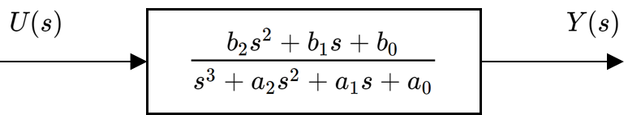

We aim to express this system in state-space form:

$$ \begin{aligned} \dot{x} &= Ax + Bu \\ y &= Cx + Du \end{aligned} $$

**Step 1**: Algebraic Rearrangement

From the transfer function:

$$ U(s) = \left(s^3 + a_2 s^2 + a_1 s + a_0 \right) X(s), \qquad Y(s) = \left(b_2 s^2 + b_1 s + b_0 \right) X(s) $$

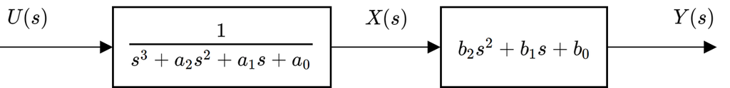

**Step 2**: Inverse Laplace Transform

Take inverse Laplace transforms:

$$ \begin{aligned} u(t) &= \dddot{x}(t) + a_2 \ddot{x}(t) + a_1 \dot{x}(t) + a_0 x(t) \\ y(t) &= b_2 \ddot{x}(t) + b_1 \dot{x}(t) + b_0 x(t) \end{aligned} $$

**Step 3**: Choose State Variables

Define state variables based on the derivatives of $x(t)$:

$$ \begin{aligned} x_1 &= x(t) \\ x_2 &= \dot{x}(t) \\ x_3 &= \ddot{x}(t) \end{aligned} $$

Then, their time derivatives become:

$$ \begin{aligned} \dot{x}_1 &= x_2 \\ \dot{x}_2 &= x_3 \\ \dot{x}_3 &= -a_0 x_1 - a_1 x_2 - a_2 x_3 + u \end{aligned} $$

**Step 4**: State-Space Representation

The resulting system in matrix form:

$$ \begin{bmatrix} \dot{x}_1 \\ \dot{x}_2 \\ \dot{x}_3 \end{bmatrix} = \begin{bmatrix} 0 & 1 & 0 \\ 0 & 0 & 1 \\ -a_0 & -a_1 & -a_2 \end{bmatrix} \begin{bmatrix} x_1 \\ x_2 \\ x_3 \end{bmatrix} + \begin{bmatrix} 0 \\ 0 \\ 1 \end{bmatrix} u(t) $$

Output equation:

$$ y(t) = \begin{bmatrix} b_0 & b_1 & b_2 \end{bmatrix} \begin{bmatrix} x_1 \\ x_2 \\ x_3 \end{bmatrix} $$

This is now in the canonical controllable companion form.

**Visual Representation**

The corresponding block diagram shows the chain of integrators for each state and the feedback paths for coefficients $a_0, a_1, a_2$, along with output weights $b_0, b_1, b_2$. This structure provides an intuitive realization of the dynamics implied by the transfer function.

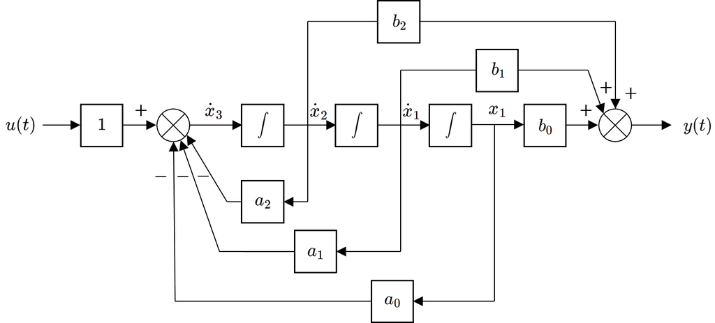

# 4. MATLAB Implementation

## 4.1. Step Response

Start with a step response example

$$ \dot{y} + 5y = 1 \quad \text{for} \quad t \geq 0, \qquad y(0) = 0$$

or

$$ \dot{y} + 5y = u(t), \qquad y(0) = 0 $$

The solution is given:

$$ y(t) = \frac{1}{5}\left( 1-e^{-5t} \right)$$

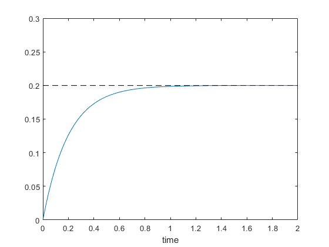

```matlab
% method 1

% define a system first
num = 1;
den = [1 5];

G = tf(num,den);

[y,tout] = step(G,2);

plot(tout,y,tout,0.2*ones(size(tout)),'k--')
ylim([0,0.3])
xlabel('time')
```

$$ \begin{align*} \dot{x} &= -5x + u \\ y &= x \end{align*} $$

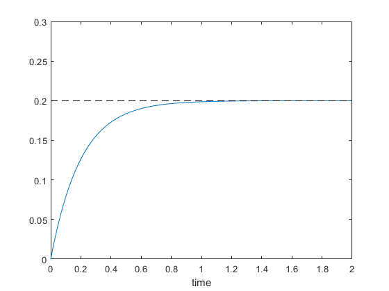

```matlab
% method 2

% define a system first
A = -5;
B = 1;
C = 1;
D = 0;
G = ss(A,B,C,D);

t = linspace(0,2,100);
u = ones(size(t));
x0 = 0;

[y,tout] = lsim(G,u,t,x0);

plot(tout,y,tout,0.2*ones(size(tout)),'k--')
ylim([0,0.3])
xlabel('time')
```

$$ \begin{align*} &\ddot{y} + 2\zeta\omega_n\dot{y} + \omega^2_n y = \omega^2_n u(t) \\ \\ \implies &\;G(s) = \frac{\omega^2_n}{s^2 + 2\zeta\omega_n s + \omega^2_n } \end{align*} $$

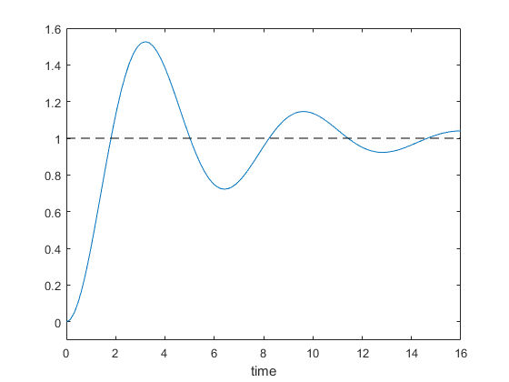

```matlab
z = 0.2;
wn = 1;

G = tf(wn^2,[1,2*z*wn,wn^2]);

[y,tout] = step(G,16);

plot(tout,y,tout,ones(size(tout)),'k--')
ylim([-0.1 1.6])
xlabel('time')
```

$$ \begin{align*} \left[ {\begin{matrix} \dot{x}_1 \\ \dot{x}_2 \\ \end{matrix} } \right] &= \left[ {\begin{matrix} 0 & 1 \\ -\omega_n^2 & -2\zeta \omega_n \\ \end{matrix} } \right] \left[ {\begin{array}{cc} x_1 \\ x_2 \\ \end{array} } \right] + \begin{bmatrix}0\\\omega_n^2\end{bmatrix}u \\ \\y & = \left[ {\begin{matrix} 1 & 0 \end{matrix} } \right] \left[ {\begin{array}{cc} x_1 \\ x_2 \\ \end{array} } \right] \end{align*} $$

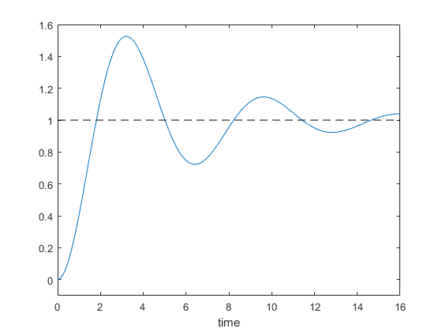

```matlab
% method 2

% define a system first
zeta = 0.2;
wn = 1;

A = [0, 1;-wn^2, -2*zeta*wn];
B = [0; wn^2];
C = [1, 0];
D = 0;
G = ss(A,B,C,D);

t = linspace(0,16,100);
u = ones(size(t));
x0 = [0; 0];

[y,tout] = lsim(G,u,t,x0);

plot(tout,y,tout,ones(size(tout)),'k--')
ylim([-0.1 1.6])
xlabel('time')
```

## 4.2. Impulse Response

Now think about the impulse response

$$ \dot{y} + 5y = \delta(t), \qquad y(0) = 0 $$

The solution is given: (why?)

$$ y(t) = h(t) = e^{-5t},\quad t\geq0$$

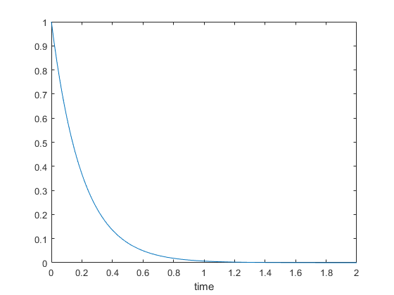

```matlab
% method 1

% define a system first
num = 1;
den = [1 5];
G = tf(num,den);

[h,tout] = impulse(G,2);

plot(tout,h), ylim([0,1])
xlabel('time')
```

$$ \begin{align*} \dot{x} &= -5x + u \\ y &= x \end{align*} $$

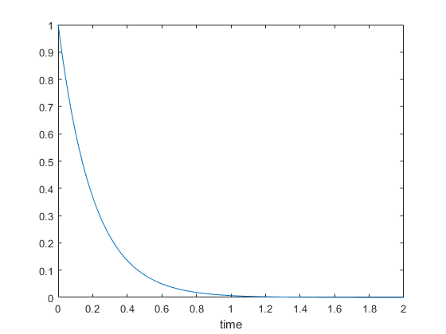

```matlab
% method 2

% define a system first
A = -5;
B = 1;
C = 1;
D = 0;
G = ss(A,B,C,D);

t = linspace(0,2,100);
u = zeros(size(t));
x0 = 1;

[h,tout] = lsim(G,u,t,x0);

plot(tout,h), ylim([0,1])
xlabel('time')
```

$$ \begin{align*} &\ddot{y} + 2\zeta\omega_n\dot{y} + \omega^2_n y = \omega^2_n \delta(t) \\ \\ \implies &\;G(s) = \frac{\omega^2_n}{s^2 + 2\zeta\omega_n s + \omega^2_n } \end{align*} $$

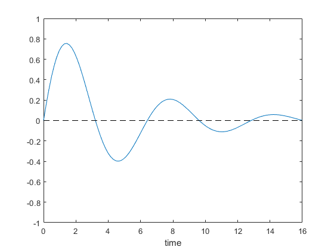

```matlab
z = 0.2;
wn = 1;

G = tf(wn^2,[1,2*z*wn,wn^2]);

[y,tout] = impulse(G,16);

plot(tout,y,tout,zeros(size(tout)),'k--')
ylim([-1 1])
xlabel('time')
```

## 4.3. Response to a General Input

Response to a **general input**

$$ \dot{x} + 5x = u(t), \qquad x(0) = 0 $$

The solution is given:

$$ x(t) = h(t)*u(t),\quad t\geq0$$

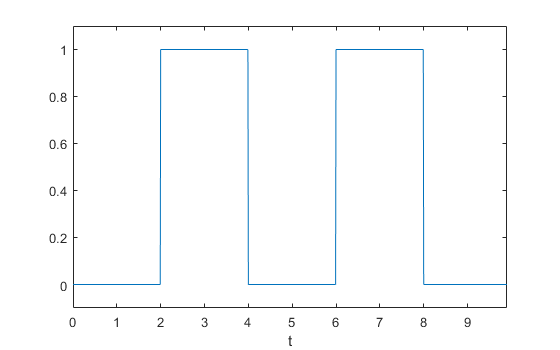

```matlab
%plot -s 560,350

% generate a general input

[f,t] = gensig('square',4,10,0.01);
plot(t,f), axis([0,9.9,-0.1,1.1])
xlabel('t')
```

$$ \begin{align*} \dot{x} &= -5x + u \\ y &= x \end{align*} $$

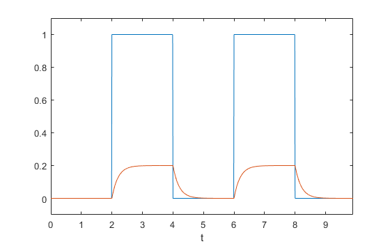

```matlab
%plot -s 560,350

% use lsim

A = -5;
B = 1;
C = 1;
D = 0;
G = ss(A,B,C,D);

x0 = 0;
[f,t] = gensig('square',4,10,0.01);
[y,tout] = lsim(G,f,t,x0);

plot(t,f), hold on
plot(tout,y), hold off, axis([0,9.9,-0.1,1.1])
xlabel('t')
```